# Combination of results from different analysis for metabolic changes in IBD patients

Jan Taubenheim

2022-05-06

```r
require(data.table)
require(ggplot2)
require(ComplexUpset)
require(clusterProfiler)
require(psych)
require(lme4)
require(lmerTest)
require(pheatmap)
```

# 1 Introduction

The general idea is to find changes in the metabolic network of IBD patients which are associated with a change the disease activity scores. I analysed data sets for the reaction activity scores, the presence/absence of reactions after context specific model reconstruction and FVA analysis using a reaction based GLMM approach. This results in sets of reactions, which are associated with the disease activity. Furthermore, I have made set enrichments for the subsystems - again something which can be compared for the different analysis.

# 2 Results

## 2.1 Reaction association

First lets look at the reactions which are shared between the different analysis.

```r
coefs.rxnExpr <- fread("./Statistics/results/rxnExpr.GLMM.Remission.intervention_coefs.csv")
sigs.rxnExpr <- coefs.rxnExpr[padj < 0.05,]
coefs.PA <- fread("./Statistics/results/PA.GLMM.Remission.intervention_coefs.csv")
sigs.PA <- coefs.PA[padj < 0.05,]
coefs.FVA <- fread("./Statistics/results/FVA.GLMM.Remission.intervention_coefs.csv")
sigs.FVA <- coefs.FVA[padj < 0.05,]

sigs <- list(rxnExpr = sigs.rxnExpr,
             PA = sigs.PA,
             FVA = sigs.FVA)

# annotations
subsystems <- fread("./Statistics/dat/subsystems.csv")
rxnAnno <- fread("../../resources/recon-store-reactions-1.tsv")
```

Here is an upset plot for the reactions.

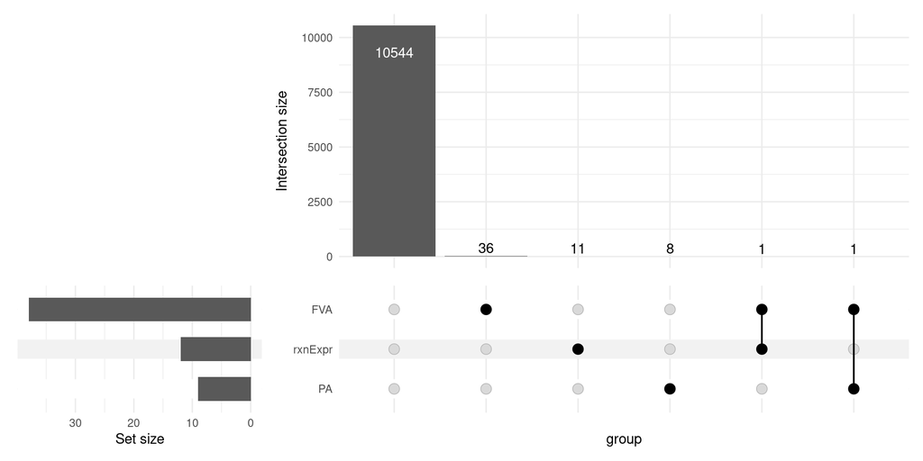

```r
rxns <- unique(c(subsystems[,reaction], unlist(sapply(sigs,function(x) x[,rxn]))))

vennMat <- matrix(0, nrow = length(rxns), ncol = length(sigs), dimnames = list(rxns, names(sigs)))
for(set.nm in names(sigs)){
    set <- sigs[[set.nm]]
    vennMat[set[,rxn],set.nm] <- 1
}

upset(as.data.frame(vennMat), intersect = colnames(vennMat))
```

There are 0 reactions which are associated in all analysis with Remission changes. Here is the complete list:

|  | abbreviation | description | formula | subsystem | ecnumber | keggId | keggorthology | cog | seed | metanetx |
| --- | --- | --- | --- | --- | --- | --- | --- | --- | --- | --- |

From all the reactions we can make another hypergeometric enrichment - which would be an overall assessment of the analysis performed.

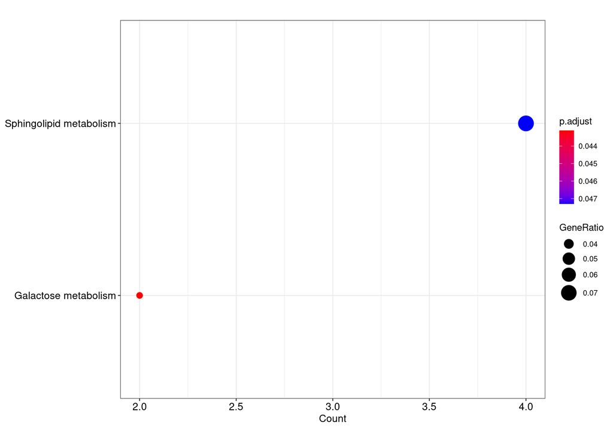

```r
hgt <- enricher(unique(unlist(sapply(sigs, function(x) x[,rxn]))), TERM2GENE = subsystems)
dotplot(hgt, x = "Count", showCategory = nrow(data.frame(hgt)))
```

Additionally, we can summarize the results from all data sets and do a GSEA as well.

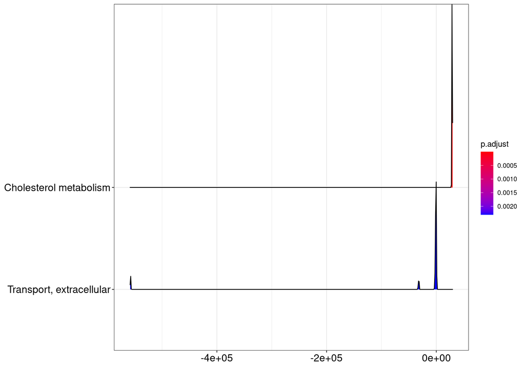

```r
# I need the cluster information to expand the estimates accordingly
cluster.rxnExpr <- fread("./Statistics/results/rxnExpr_DBSCAN_Cluster.csv")
cluster.PA <- fread("./Statistics/results/PA_DBSCAN_Cluster.csv")
cluster.FVA <- fread("./Statistics/results/FVA_DBSCAN_Cluster.csv")

# merge the cluster with the coef table
coefs.rxnExpr <- merge(coefs.rxnExpr,
                       cluster.rxnExpr[,.(rxn,rep.rxn)],
                       by.x = "rxn",
                       by.y = "rep.rxn",
                       suffix = c("",".clustered"),
                       keep.x = TRUE)
coefs.PA <- merge(coefs.PA,
                       cluster.PA[,.(rxn,rep.rxn)],
                       by.x = "rxn",
                       by.y = "rep.rxn",
                       suffix = c("",".clustered"),
                       keep.x = TRUE)
coefs.FVA <- merge(coefs.FVA,
                       cluster.FVA[,.(rxn,rep.rxn)],
                       by.x = "rxn",
                       by.y = "rep.rxn",
                       suffix = c("",".clustered"),
                       keep.x = TRUE)

# get the common columns
clmns <- intersect(colnames(coefs.rxnExpr), colnames(coefs.PA))
clmns <- intersect(colnames(coefs.FVA), clmns)
# merge on
coefs.all <- rbind(
                   cbind(coefs.rxnExpr[,..clmns], data.set = "rxnExpr"),
                   cbind(coefs.PA[,..clmns], data.set = "PA"),
                   cbind(coefs.FVA[,..clmns], data.set = "FVA"))

gseaTab <- coefs.all[,.(Estimate.sum = sum(Estimate)), by = rxn.clustered]
gseaVector <- gseaTab[,Estimate.sum]
names(gseaVector) <- gseaTab[,rxn.clustered]
gseaVector <- sort(gseaVector, decreasing = TRUE)

gsea <- GSEA(gseaVector,
             TERM2GENE = subsystems,
             minGSSize = 3,
             maxGSSize = 1E6,
             verbose = FALSE,
             pvalueCutoff = 0.05)

if(nrow(data.frame(gsea)) > 0){
    ridgeplot(gsea)
}
```

There question remains, how to display that in a concise manner - the answer: in a simple boxplot for all the significant reactions in the subsystems and their estimates.

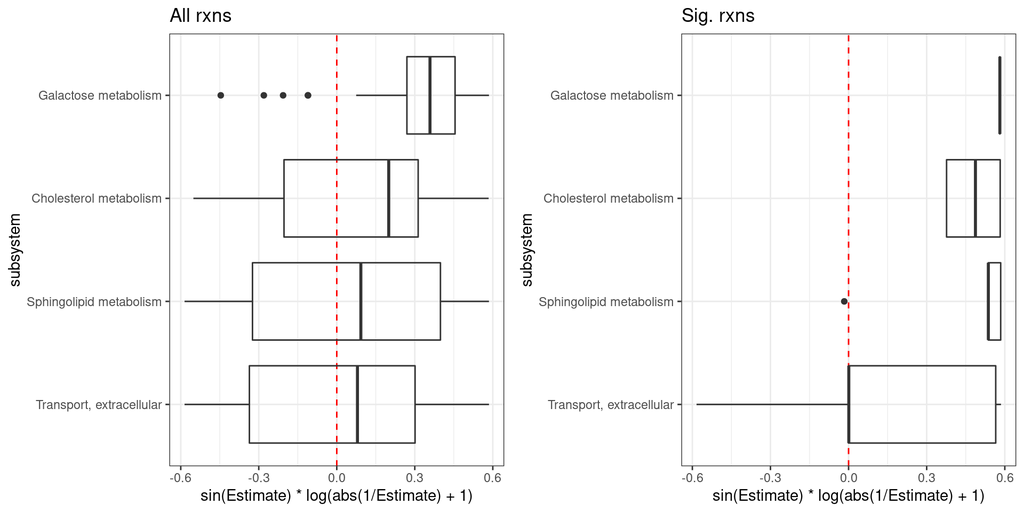

```r
sig.subs<- unique(c(data.frame(hgt)[,"ID"], data.frame(gsea)[,"ID"]))

coefs.all.subs <- merge(coefs.all, subsystems, by.x = "rxn.clustered", by.y = "reaction", keep.x = TRUE)
sub.order <- coefs.all.subs[,.(od = median(Estimate)), by = subsystem]
coefs.all.subs[,subsystem := factor(subsystem, level = sub.order[order(od), subsystem])]

plt.sub.est.all <- ggplot(coefs.all.subs[subsystem %in% sig.subs,], aes(x= sin(Estimate)*log(abs(1/Estimate)+1), y = subsystem)) +
    geom_vline(xintercept = 0, color = "red", linetype = 2)+
    geom_boxplot(fill = NA) +
    ggtitle("All rxns")+
    theme_bw()
plt.sub.est.sig <- ggplot(coefs.all.subs[subsystem %in% sig.subs & padj <=0.05,], aes(x= sin(Estimate)*log(abs(1/Estimate)+1), y = subsystem)) +
    geom_vline(xintercept = 0, color = "red", linetype = 2)+
    geom_boxplot(fill = NA) +
    ggtitle("Sig. rxns")+
    theme_bw()
cowplot::plot_grid(plt.sub.est.all, plt.sub.est.sig)
```

## 2.2 Subsystem association

Similar we can make a summary of the subsystems by comparing the different subsystems which have been enriched in the different analysis and with GSEA and HGT.

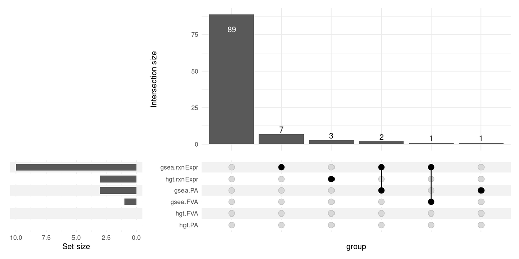

```r
gsea.rxnExpr <- readRDS("Statistics/results/rxnExpr.GSEA.Remission.intervention_GSEAResult.RDS")
gsea.PA <- readRDS("Statistics/results/PA.GSEA.Remission.intervention_GSEAResult.RDS")
gsea.FVA <- readRDS("Statistics/results/FVA.GSEA.Remission.intervention_GSEAResult.RDS")

vennMat.subsys <- matrix(0, ncol = 2*length(sigs), nrow = length(unique(subsystems[,subsystem])),
                         dimnames = list(unique(subsystems[,subsystem]),
                                         paste0(sort(rep(c("hgt.","gsea."), length(sigs))), rep(names(sigs),2)))
                         )
for(n in names(sigs)){
    hgt <- enricher(sigs[[n]][,rxn],TERM2GENE = subsystems)
    vennMat.subsys[data.frame(hgt)[,"ID"], paste0("hgt.",n)] <- 1
    gsea <- get(paste0("gsea.",n))
    vennMat.subsys[data.frame(gsea)[,"ID"], paste0("gsea.",n)] <- 1
}

upset(as.data.frame(vennMat.subsys), intersect = colnames(vennMat.subsys))
```

```r
dt.vennMat.subsys <- data.table(vennMat.subsys, total = rowSums(vennMat.subsys), keep.rownames = TRUE)

DT::datatable(dt.vennMat.subsys[total >= 1,])
```

|  | rn | gsea.rxnExpr | gsea.PA | gsea.FVA | hgt.rxnExpr | hgt.PA | hgt.FVA | total |
| --- | --- | --- | --- | --- | --- | --- | --- | --- |
| 1 | Bile acid synthesis | 1 | 0 | 0 | 0 | 0 | 0 | 1 |
| 2 | Cholesterol metabolism | 1 | 1 | 0 | 0 | 0 | 0 | 2 |
| 3 | Chondroitin synthesis | 1 | 0 | 0 | 0 | 0 | 0 | 1 |
| 4 | Drug metabolism | 1 | 0 | 0 | 0 | 0 | 0 | 1 |
| 5 | Fatty acid oxidation | 1 | 0 | 0 | 0 | 0 | 0 | 1 |
| 6 | Fatty acid synthesis | 1 | 1 | 0 | 0 | 0 | 0 | 2 |
| 7 | Galactose metabolism | 0 | 0 | 0 | 1 | 0 | 0 | 1 |
| 8 | Glycerophospholipid metabolism | 0 | 0 | 0 | 1 | 0 | 0 | 1 |
| 9 | Heme synthesis | 0 | 0 | 0 | 1 | 0 | 0 | 1 |
| 10 | Keratan sulfate degradation | 1 | 0 | 0 | 0 | 0 | 0 | 1 |

[output cut: 4 more lines]

There is(are) exactly 0 subsystem(s) which is(are) found across all analysis. That is:

```r
tbl.subsys <- rxnAnno[subsystem %in% rownames(vennMat.subsys)[rowSums(vennMat.subsys) == ncol(vennMat.subsys)],]
DT::datatable(tbl.subsys)
```

|  | abbreviation | description | formula | subsystem | ecnumber | keggId | keggorthology | cog | seed | metanetx |
| --- | --- | --- | --- | --- | --- | --- | --- | --- | --- | --- |

## 2.3 Diversity measures

An interesting finding was, that generally there were more reactions which, if present/active, there was a reduction in disease activity. This can be either an effect that certain reactions are really blocked/reduced in activity if Remission scores are high or it is a result of a reduced metabolic diversity in higher inflammation states. To test that one can correlate the Remission score with the diversity measures of the different analysis.

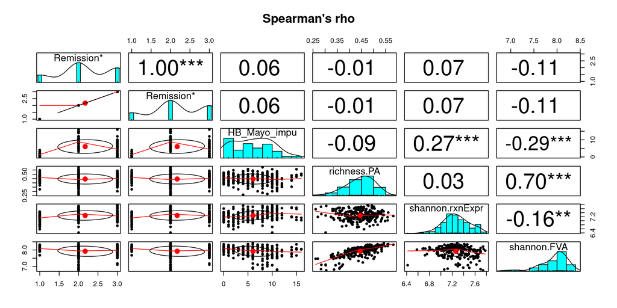

```r
diversity <- fread("Statistics/results/diversityMeasures.csv")
pairs.panels(diversity[,.(Remission,Remission,HB_Mayo_impu,richness.PA, shannon.rxnExpr, shannon.FVA)],
           method = "spearman",
           stars = TRUE,
           main = "Spearman's rho")
```

So there are slight correlation, which poses the question, whether this signal remains, if tested in a linear mixed model to correct for PatientID independence.

```r
mod.richness.PA <- glmer(data = diversity,
                        factor(Remission) ~ richness.PA + (1|PatientID),
                        family = binomial)
mod.shannon.rxnExpr <- glmer(data = diversity,
                        factor(Remission) ~ shannon.rxnExpr + (1|PatientID),
                        family = binomial)
mod.shannon.FVA <- glmer(data = diversity,
                        factor(Remission) ~ shannon.FVA + (1|PatientID),
                        family = binomial)


stats <- data.table(rbind(
                          coef(summary(mod.richness.PA)),
                          coef(summary(mod.shannon.rxnExpr)),
                          coef(summary(mod.shannon.FVA))),
                    keep.rownames = TRUE)[rn != "(Intercept)",]
stats[,padj := p.adjust(`Pr(>|z|)`, method = "BH")]
DT::datatable(stats)
```

|  | rn | Estimate | Std. Error | z value | Pr(>\|z\|) | padj |
| --- | --- | --- | --- | --- | --- | --- |
| 1 | richness.PA | -3.76578846850238 | 26.7056682001549 | -0.141010831119385 | 0.887861385846521 | 0.887861385846521 |
| 2 | shannon.rxnExpr | 2.2292463540214 | 4.3101576495618 | 0.517207614029626 | 0.605011237470862 | 0.887861385846521 |
| 3 | shannon.FVA | -2.2145585369472 | 3.84787740746409 | -0.575527310888702 | 0.564934725487822 | 0.887861385846521 |

## 2.4 PCA for clustering

Another idea is to use the different significant reactions and use the data to make a ordination to get a feeling how well we can separate the different samples form each other by Remission scores.

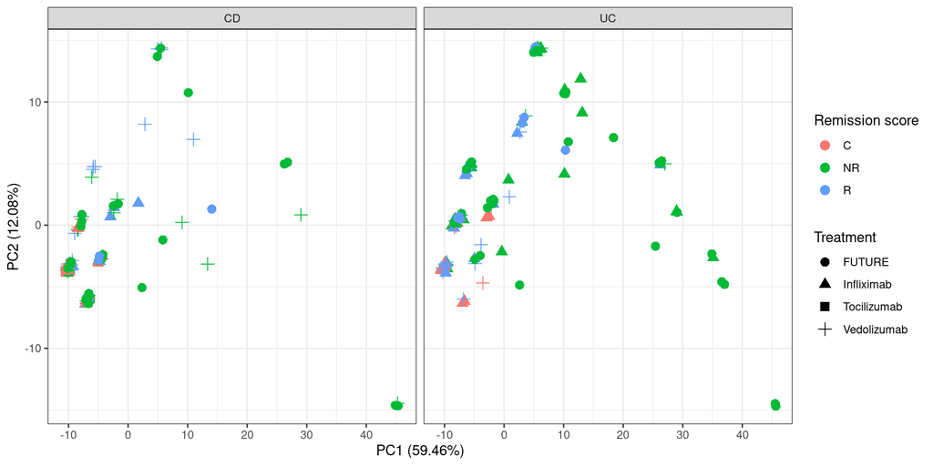

```r
rxnExpr <- read.csv("../results/RxnExpression/rxnExpr.GL10-L50-GU90.colormore3D.csv", row.names=1)
rxnExpr <- rxnExpr[sigs.rxnExpr[,rxn],]
PA <- read.csv("../results/ModelAnalysis/rxnIdMat.GL10-L50-GU90.MatjesAbsorption.colormore3D.csv", row.names=1)
PA <- PA[sigs.PA[,rxn],]
# make PA to integer
PA2 <- PA
PA2[,] <- 0
PA2[PA == "True"] <- 1
PA <- PA2
FVA.range <- read.csv("../results/FVA/rangeFVA.GL10-L50-GU90.MatjesAbsorption.colormore3D.csv", row.names=1)
FVA.range <- FVA.range[sigs.FVA[coef == "range",rxn],]
FVA.center <- read.csv("../results/FVA/centerFVA.GL10-L50-GU90.MatjesAbsorption.colormore3D.csv", row.names=1)
FVA.center <- FVA.center[sigs.FVA[coef == "center",rxn],]


# transform the PA data to jaccard distances, otherwise it is less meaningful
PA.dist <- as.matrix(dist(t(PA), method = "binary"))
mat.all <- t(rbind(rxnExpr, PA.dist, FVA.center, FVA.range))

pca <- prcomp(mat.all, scale = TRUE, center = TRUE)
pca.x <- merge(data.table(pca[["x"]], keep.rownames = TRUE), diversity, by.x = "rn", by.y = "SeqID")
pca.var <- pca[["sdev"]]^2/sum(pca[["sdev"]]^2)*100

pca.plot <- ggplot(pca.x, aes(x=PC1,y=PC2)) +
    #scale_color_gradient(low = "blue", high ="red") +
    geom_point(aes(color = Remission, shape = Treatment),size = 3) +
    theme_bw() +
    facet_grid(~Diagnosis) +
    labs(y = paste0("PC2 (", round(pca.var[2],2),"%)"),
         x = paste0("PC1 (", round(pca.var[1],2),"%)"),
         color = "Remission score")
pca.plot
```

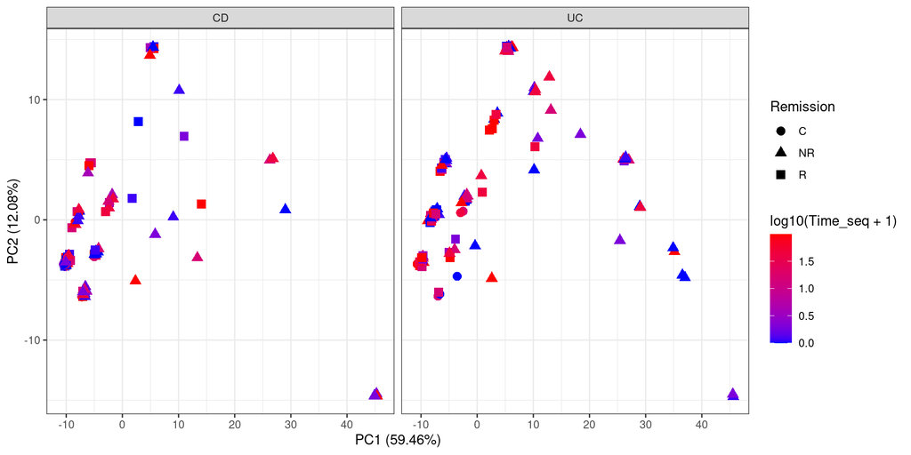

```r
pca.plot <- ggplot(pca.x, aes(x=PC1,y=PC2)) +
    scale_color_gradient(low = "blue", high ="red") +
    geom_point(aes(color = log10(Time_seq+1), shape =Remission),size = 3) +
    theme_bw() +
    facet_grid(~Diagnosis) +
    labs(y = paste0("PC2 (", round(pca.var[2],2),"%)"),
         x = paste0("PC1 (", round(pca.var[1],2),"%)"))
pca.plot
```

```r
## only the rxns common in all
#rxns <- rownames(vennMat)[rowSums(vennMat) == ncol(vennMat)]
#PA.common.dist <- as.matrix(dist(t(PA[rxns,])))
#FVA.common.range  <- FVA.range[rownames(FVA.range) %in% rxns,]
#FVA.common.center <- FVA.center[rownames(FVA.center) %in% rxns,]
#rxnExpr.common <- rxnExpr[rxns,]
#mat.common.all <- t(rbind(rxnExpr.common, PA.common.dist, FVA.common.range))
#pca.common <- prcomp(mat.common.all, scale = TRUE, center = TRUE)
##
#pca.common.x <- merge(data.table(pca.common[["x"]], keep.rownames = TRUE), diversity, by.x = "rn", by.y = "SeqID")
#pca.common.var <- pca.common[["sdev"]]^2/sum(pca.common[["sdev"]]^2)*100
##
#pca.common.plot <- ggplot(pca.common.x, aes(x=PC1,y=PC2)) +
##    scale_color_gradient(low = "blue", high ="red") +
#    geom_point(aes(color = Remission, shape = Diagnosis),size = 3) +
#    theme_bw() +
#    facet_grid(~Diagnosis) +
#    labs(y = paste0("PC2 (", round(pca.common.var[2],2),"%)"),
#         x = paste0("PC1 (", round(pca.common.var[1],2),"%)"),
#         color = "Remission")
#pca.common.plot
```

# 3 Finding correlated exchange reactions

In order to detect those metabolites which probably show an influence on the metabolic network and the significant reactions I correlated the values of the significant reactions for presence/absence and FVA center and range to the values of the values to the exchange reactions. I took the mean of the correlation coefficient for each rxn/Ex_rxn pair and kept the top 1% values for each rxn. I further calculated the mean of all coefficients for the significant rxns in the GLMMs and multiplied the two values. This left me with a value which describes the strength of the correlation for a rxns to the exchange of a metabolite and the strength of the rxn change to the Remission score. It thus gives us values to rank the different metabolites to the change in Remission.

NOTE: I reversed the correlation coefficients and the GLMM coefficients for the results of the FVA center analysis in order to comply with a more readily interpretable result. This means more uptake of the metabolite will increase the be positively associated with an increase in the center of the rxn in question.

[figure not shown]

```r
all.Excors <- fread("Statistics/results/ExCorrelation_summary2.csv")
topcor <- all.Excors[est_src == "Remission" & aim == "intervention",]



# filter the exchange reactions, which show a significant effect which is different from 0
topcor.ttests <- topcor[est_src == "Remission", .(p.value = tryCatch({
                                                    t.test(score_abs_mean)[["p.value"]]
                                                }, error = function(e){1.0}),
                                                score_mean = mean(score_mean),
                                                score_sum = sum(score_mean),
                                                score_abs_mean = mean(score_abs_mean),
                                                score_absabs_mean = mean(score_absabs_mean), # model estimates and correlations are transformed to positive values
                                                score_abs_sum = sum(score_abs_mean),
                                                score_absabs_sum = sum(score_absabs_mean),
                                                NoRxns = .N,
                                                Metabolite = unique(Metabolite),
                                                r_direction_mean = mean(r_direction),
                                                compartment = unique(compartment),
                                                main.direction = unique(main.direction)
                                                ), by = .(rn)]
topcor.ttests[,padj := p.adjust(p.value, method = "BH")]

#topcor.ttests[,rxn_base := gsub("\\[.\\]","",rn)]

#rxnAnno[,rxn_base := gsub("\\[.\\]","",abbreviation)]
#topcor.ttests <- merge(topcor.ttests, rxnAnno[,.(rxn_base, description)], by = "rxn_base")
#topcor.ttests[,description := gsub(".* of","", description)]
#topcor.ttests[,Metabolite := factor(description, levels = unique(description[order(Remission_score_sum]))]
#topcor.ttests[, compartment := "Colon"]
#topcor.ttests[grep(".*\\[e\\]",rn), compartment := "Blood"]


# get those which have the largest deviation from 0 (based on the ttest p.value)
top100 <- unique(topcor.ttests[order(score_absabs_sum, decreasing = TRUE),rn])[1:100]#[padj < 0.05, rn][]
#setkey(topcor.ttests, "rn")


topcor[,Metabolite := factor(Metabolite, levels = unique(Metabolite)[order(topcor[,.(val = mean(score_abs_mean)), by = .(rn)][,val])])]

plt.excor <- ggplot(topcor[est_src == "Remission" & rn %in% top100 ,], aes(x = Metabolite, y = sin(score_abs_mean)*log(abs(1/score_abs_mean)+1), fill = main.direction)) +
    geom_boxplot() +
    theme_bw() +
    theme(axis.text.x = element_text(angle = 45, hjust = 1 , vjust =1))+
    facet_grid(~compartment, scale = "free_x")
plt.excor
```

```r
DT::datatable(topcor.ttests)
```

|  | rn | p.value | score_mean | score_sum | score_abs_mean | score_absabs_mean | score_abs_sum | score_absabs_sum | NoRxns | Metabolite | r_direction_mean | compartment | main.direction | padj |
| --- | --- | --- | --- | --- | --- | --- | --- | --- | --- | --- | --- | --- | --- | --- |
| 1 | EX_3mob[e] | 1 | -109.909501155334 | -109.909501155334 | -248.866741549525 | 1563.84829674911 | -248.866741549525 | 1563.84829674911 | 1 | 3-Methyl-2-Oxobutanoate | 1 | Blood | import | 1 |
| 2 | EX_3mop[e] | 1 | -105.792065353118 | -105.792065353118 | -317.376196059355 | 1994.35336576448 | -317.376196059355 | 1994.35336576448 | 1 | 3-Methyl-2-Oxopentanoate | 1 | Blood | import | 1 |
| 3 | EX_2m3hvac[e] | 0.0137843289718658 | 0.743626387808294 | 4.46175832684976 | 0.775895871174126 | 0.800853385949258 | 4.65537522704476 | 4.80512031569555 | 6 | 2-Methyl-3-Hydroxy-Valerate | 2.5 | Blood | export | 0.180714422693075 |
| 4 | EX_bhb[e] | 0.35198855148221 | -59.2403524182606 | -533.163171764345 | -64.5018921552692 | 65.8855435340684 | -580.517029397423 | 592.969891806616 | 9 | Transport of (R)-3-Hydroxybutanoate via H+ Symport | 2.33333333333333 | Blood | both | 0.694043273076629 |
| 5 | EX_eic21114tr[e] | 0.349161673008484 | -51.8229372004366 | -518.229372004366 | -57.7649711048026 | 59.0719126948418 | -577.649711048026 | 590.719126948418 | 10 | Trans, Cis, Cis-2, 11, 14-Eicosatrienoic Acid | 2.3 | Blood | export | 0.694043273076629 |
| 6 | EX_adprbp[e] | 0.0611975559166024 | -0.455227968712587 | -1.36568390613776 | 0.510855841980442 | 0.557095190434776 | 1.53256752594132 | 1.67128557130433 | 3 | ADPribose 2'-Phosphate | -2 | Blood | export | 0.180714422693075 |
| 7 | EX_bildglcur[e] | 0.0178347057071945 | 0.775449950995669 | 3.10179980398267 | 0.775449950995669 | 0.775449950995669 | 3.10179980398267 | 3.10179980398267 | 4 | Bilirubin Beta-Diglucuronide | 2.75 | Blood | export | 0.180714422693075 |
| 8 | EX_ctp[e] | 1 | 0.665422403203195 | 0.665422403203195 | 0.665422403203195 | 0.665422403203195 | 0.665422403203195 | 0.665422403203195 | 1 | CTP | 2 | Blood | export | 1 |
| 9 | EX_nadp[e] | 0.0611975559166024 | -0.384813606792037 | -1.15444082037611 | 0.510855841980442 | 0.557095190434776 | 1.53256752594132 | 1.67128557130433 | 3 | Nicotinamide Adenine Dinucleotide Phosphate | -2 | Blood | import | 0.180714422693075 |
| 10 | EX_pcrn[e] | 1 | 0.685554608204629 | 0.685554608204629 | 0.685554608204629 | 0.685554608204629 | 0.685554608204629 | 0.685554608204629 | 1 | O-Propanoylcarnitine | 2 | Blood | export | 1 |

[output cut: 80 more lines]

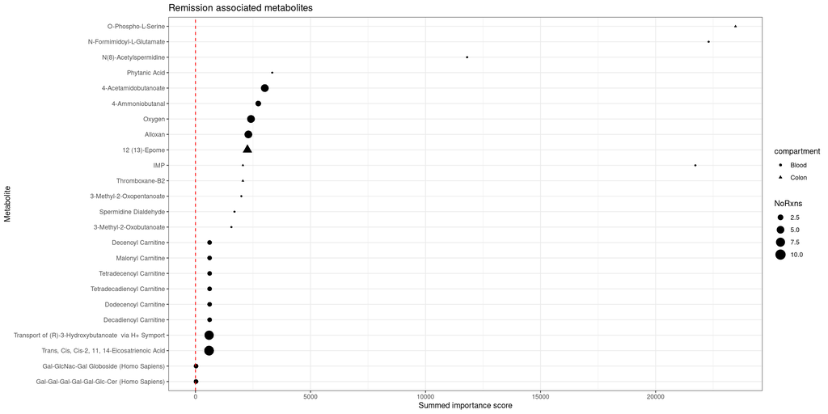

```r
# another way of plotting would be summing the scores by exchange reaction
topcor.ttests[,Metabolite := factor(Metabolite,levels = unique(Metabolite[order(score_absabs_sum)]))]
topcor.sums.plt <- ggplot(topcor.ttests[order(abs(score_absabs_sum),decreasing = T)[1:25],],
                          aes(x = score_absabs_sum,
                              y = Metabolite,
                              size = NoRxns,
                              #color = main.direction,
                              shape = compartment
                              )) +
    geom_point() +
    geom_vline(linetype = 2, color = "red", xintercept = 0) +
    labs(x = "Summed importance score", title = "Remission associated metabolites") +
    theme_bw()
topcor.sums.plt
```

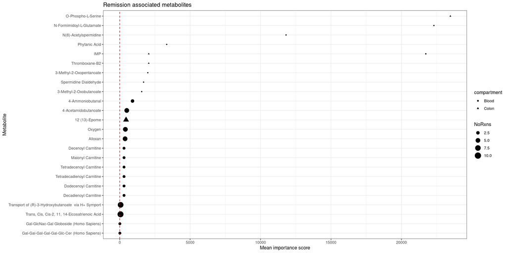

```r
topcor.ttests[,Metabolite := factor(Metabolite,levels = unique(Metabolite[order(score_absabs_mean)]))]
topcor.sums.plt <- ggplot(topcor.ttests[order(abs(score_absabs_sum),decreasing = T)[1:25],],
                          aes(x = score_absabs_mean,
                              y = Metabolite,
                              size = NoRxns,
                              #color = main.direction,
                              shape = compartment
                              )) +
    geom_point() +
    geom_vline(linetype = 2, color = "red", xintercept = 0) +
    labs(x = "Mean importance score", title = "Remission associated metabolites") +
    theme_bw()
topcor.sums.plt
```

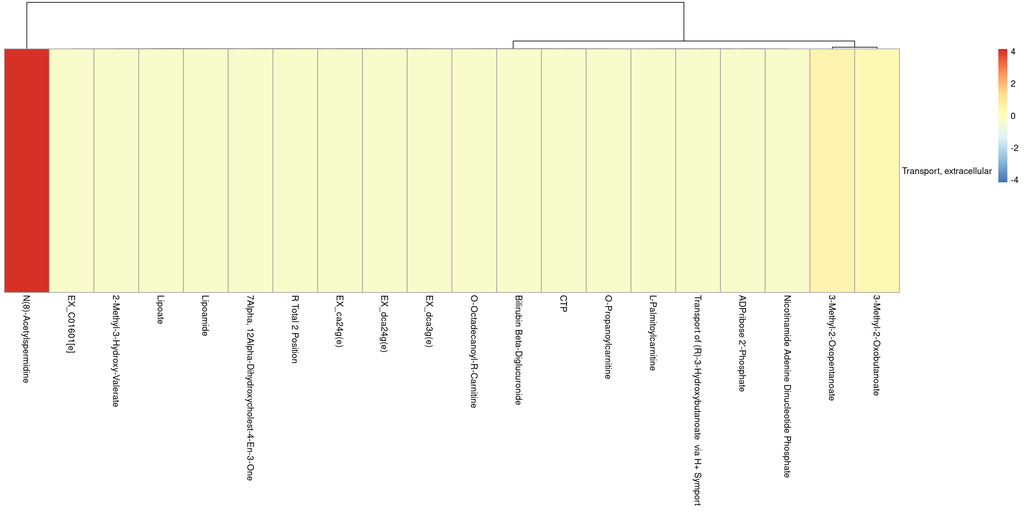

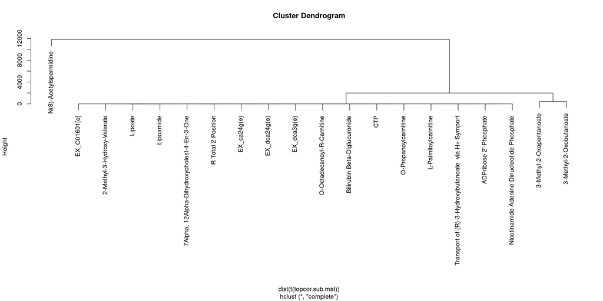

```r
# relating these exchange reactions back to the subsystems

topcor.subsystems <- topcor[rn %in% top100,
                            .(score_mean = mean(score_mean,na.rm =TRUE),
                              score_sum = sum(score_mean, na.rm = TRUE),
                              score_absabs_mean = mean(score_absabs_mean, na.rm = TRUE),
                              score_absabs_sum = sum(score_absabs_mean, na.rm = TRUE),
                              N_rxns = .N,
                             # compartment = unique(compartment),
                             # Metabolite = unique(Metabolite),
                              main.direction = unique(main.direction)
                              ),
                            by=.(Metabolite,subsystem)]

sig.subs <- unique(c(data.frame(hgt)[,"ID"],data.frame(gsea)[,"ID"]))
topcor.subsystems <- topcor.subsystems[subsystem %in% sig.subs,]

topcor.sub.mat <- dcast(data.frame(topcor.subsystems),
                        subsystem~Metabolite,
                        value.var = "score_absabs_sum",
                        fill = 0)

if(sum(dim(topcor.sub.mat)) >2){

    rownames(topcor.sub.mat) <- topcor.sub.mat[,1]
    topcor.sub.mat<-  topcor.sub.mat[,-1]
    if(ncol(topcor.sub.mat)==1){
        pheatmap::pheatmap(topcor.sub.mat,
                           scale = "row",
                           cluster_cols = FALSE)
        # get a new order for the metabolites
        clust.subsystems <- hclust(dist(topcor.sub.mat))
        # plot a dendogram
        plot(clust.subsystems)
        topcor.subsystems[,subsystem := factor(subsystem, levels = clust.subsystems$label[clust.subsystems$order])]
    } else if(nrow(topcor.sub.mat) == 1){
        pheatmap::pheatmap(topcor.sub.mat,
                           scale = "row",
                           cluster_rows = FALSE)
        # get a new order for the metabolites
        clust.metabolites <- hclust(dist(t(topcor.sub.mat)))
        # plot a dendogram
        plot(clust.metabolites)
        topcor.subsystems[,Metabolite := factor(Metabolite, levels = clust.metabolites$label[clust.metabolites$order])]
    } else {
        pheatmap::pheatmap(topcor.sub.mat,
                           scale = "row")
        # get a new order for the metabolites
        clust.subsystems <- hclust(dist(topcor.sub.mat))
        clust.metabolites <- hclust(dist(t(topcor.sub.mat)))
        # plot a dendogram
        plot(clust.subsystems)
        plot(clust.metabolites)
        topcor.subsystems[,Metabolite := factor(Metabolite, levels = clust.metabolites$label[clust.metabolites$order])]
        topcor.subsystems[,subsystem := factor(subsystem, levels = clust.subsystems$label[clust.subsystems$order])]
    }
}
```

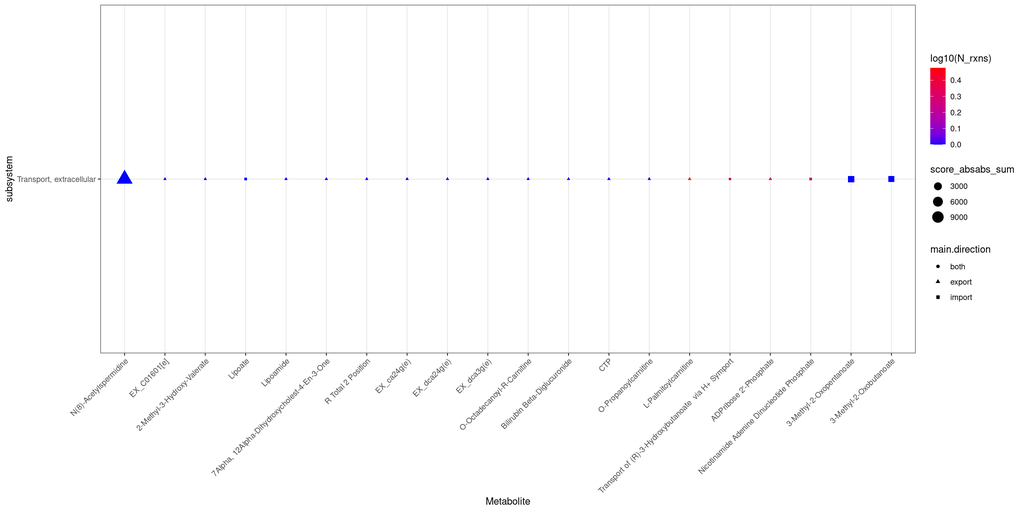

```r
ggplot(topcor.subsystems, aes(x=Metabolite, y = subsystem, color = log10(N_rxns), size = score_absabs_sum)) +
    geom_point(aes(shape = main.direction)) +
    scale_color_gradient(high = "red",low = "blue")+
    theme_bw()+
#    ggtitle("Metabolites with no. of targets > 1") +
    theme(axis.text.x = element_text(angle = 45, hjust = 1 , vjust =1))
```

```r
#    facet_grid(~compartment, scale = "free_x")



#topcor.subsystems <- topcor.merge[rn %in% topcor.ttests[NoRxns == 1, rn] & !is.na(Remission_score),
#                            .(Remission_score_mean = mean(Remission_score,na.rm =TRUE),
#                              Remission_score_sum = sum(Remission_score, na.rm = TRUE),
#                              N_rxns = .N),
#                            by=.(rn,subsystem,main.direction)]
#topcor.subsystems[, Remission_score_direction := (as.integer(Remission_score_sum>0)*2)-1]
#topcor.subsystems[, compartment := "Colon"]
#topcor.subsystems[grep(".*\\[e\\]",rn), compartment := "Blood"]
#
#ggplot(topcor.subsystems[Remission_score_direction <0,], aes(x=Metabolite, y = subsystem)) +
#    scale_shape_manual(values=c(25,24))+
#    geom_point(aes(shape = as.factor(Remission_score_direction), fill = main.direction, color = main.direction)) +
##    scale_fill_gradient2(high = "red",low = "blue",mid = "light grey",midpoint = 0)+
#    theme_bw()+
#   # guides(shape = "none")+
#    ggtitle("Metabolites with exactly 1 target") +
#    theme(axis.text.x = element_text(angle = 45, hjust = 1 , vjust =1, size = 10))+
#    facet_grid(~compartment, scale = "free_x")
#
#ggplot(topcor.subsystems[Remission_score_direction >0,], aes(x=Metabolite, y = subsystem)) +
#    scale_shape_manual(values=c(24))+
#    geom_point(aes(shape = as.factor(Remission_score_direction), fill = main.direction, color = main.direction)) +
##    scale_fill_gradient2(high = "red",low = "blue",mid = "light grey",midpoint = 0)+
#    theme_bw()+
#   # guides(shape = "none")+
#    ggtitle("Metabolites with exactly 1 target ") +
#    theme(axis.text.x = element_text(angle = 45, hjust = 1 , vjust =1, size = 8))+
#    facet_grid(~compartment, scale = "free_x")
```